# Day-2 (Functions, File I/O and data visualization)

## Tables and data visualization

Tables have many interesting properties. It can be perform basic plot using this. For example, if we need to plot sepal length vs sepal width, we can do this:

scatter(data_table.sepal_length, data_table.sepal_width);

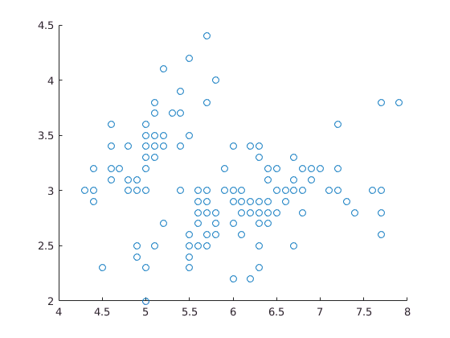

We can color code it based on plant name.

unique_names = unique(data_table.plant_name);

% Colors are 3 column vectors in matlab. It is a decimal form of RGB. Look up color specification in matlab

% red is [1,0,0] (only red). green is [0,1,0] and blue is [0,0,1].

plant_color = zeros(size(data_table.plant_name,1),3);

% Let's give the first red color (make first column 1 for these)

indices_of_plant_1 = ismember(data_table.plant_name, unique_names{1});

plant_color(indices_of_plant_1,1) = 1; % {} is required to keep the plant_color variable a cell. Replaces plant name cell with color cell.

% For the other two colors

plant_color(ismember(data_table.plant_name, unique_names{2}),2) = 1; %(make second column 1 - green)

plant_color(ismember(data_table.plant_name, unique_names{3}),3) = 1; %(make third column 1 - blue)

% We can add it to our table

data_table = [data_table, table(plant_color)];

% Plotting with color

scatter(data_table.sepal_length, data_table.sepal_width, 10, data_table.plant_color); % 10 indicates marker size

xlabel('Sepal Length'), ylabel('Sepal Width');

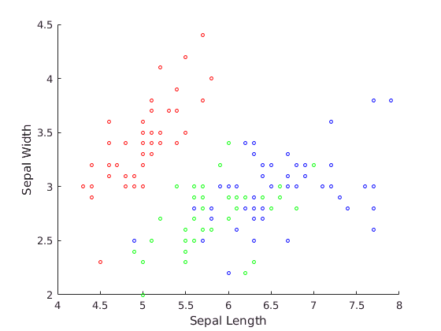

scatter(data_table.petal_length, data_table.petal_width, 15, data_table.plant_color); % 10 indicates marker size

xlabel('Petal Length'), ylabel('Petal Width');

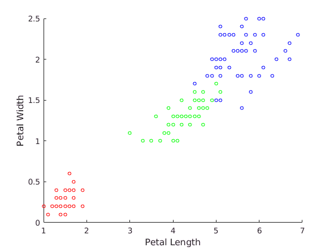

scatter(data_table.sepal_length, data_table.petal_width, 20, data_table.plant_color); % 10 indicates marker size

xlabel('Sepal Length'), ylabel('Petal Width');

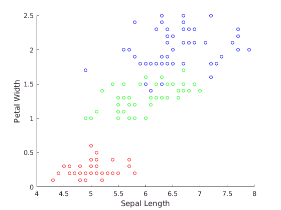

scatter(data_table.petal_length, data_table.sepal_width, 30, data_table.plant_color); % 10 indicates marker size

xlabel('Petal Length'), ylabel('Sepal Width');

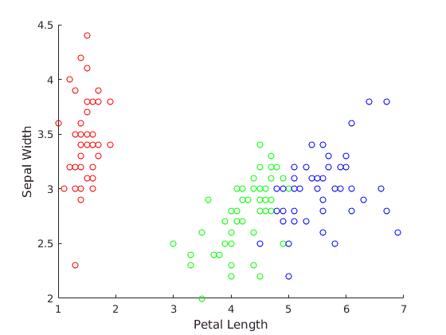

Play around with the data set more. Look at sepal length-width ratio and add it to the table. Do the same with petals. Plot them with different color based on species

# Functions (solutions)

## Max finder function

function [max] = max_finder(number_list)

max = number_list(1);

for curr_num = number_list

if (curr_num > max)

max = curr_num;

end

end

end

## Prime number function

function [prime] = isnumberprime(number)

% This function outputs prime=true when the number is prime, and prime=false when it is not prime.

divisors = 2:number-1;

% assume prime

prime = true;

for curr_divisor = divisors

if mod(number, curr_divisor) == 0

prime = false;

break;

end

end

end

## Factorial (recursive) function

function [output] = factorial_of(number)

if number == 1

output = 1;

else

output = number * factorial_of(number - 1);

end

end

## Fibonacci (recursive) function

function [output] = fibonacci(number)

if number == 1

output = 1;

elseif number == 2

output = 1;

else

output = fibonacci(number - 1) + fibonacci(number - 2);

end

end